# StudentSuccess

# Machine Learning

```python
df.to_excel("new_df.xlsx", index=False)
```

```python
df.info()
```

```
<class 'pandas.core.frame.DataFrame'>
Index: 6378 entries, 0 to 6606
Data columns (total 25 columns):
 #   Column                      Non-Null Count  Dtype
---  ------                      --------------  -----
 0   Hours_Studied               6378 non-null   int64
 1   Attendance                  6378 non-null   int64
 2   Parental_Involvement        6378 non-null   object
 3   Access_to_Resources         6378 non-null   object
 4   Extracurricular_Activities  6378 non-null   object
 5   Sleep_Hours                 6378 non-null   int64
 6   Previous_Scores             6378 non-null   int64
 7   Motivation_Level            6378 non-null   object
 8   Internet_Access             6378 non-null   object
 9   Tutoring_Sessions           6378 non-null   int64
```

[output cut: 17 more lines]

```python
df.head()
```

|  | Hours_Studied | Attendance | Parental_Involvement | Access_to_Resources | Extracurricular_Activities | Sleep_Hours | Previous_Scores | Motivation_Level | Internet_Access | Tutoring_Sessions | ... | Learning_Disabilities | Parental_Education_Level | Distance_from_Home | Gender | Exam_Score | Letter_Grade | GPA | Score_Difference | Attendance_Pct | pass_fail |
| --- | --- | --- | --- | --- | --- | --- | --- | --- | --- | --- | --- | --- | --- | --- | --- | --- | --- | --- | --- | --- | --- |
| 0 | 23 | 84 | Low | High | No | 7 | 73 | Low | Yes | 0 | ... | No | High School | Near | Male | 67 | D+ | 1.3 | 6 | 80 | fail |
| 1 | 19 | 64 | Low | Medium | No | 8 | 59 | Low | Yes | 2 | ... | No | College | Moderate | Female | 61 | F | 0.0 | -2 | 60 | fail |
| 2 | 24 | 98 | Medium | Medium | Yes | 7 | 91 | Medium | Yes | 2 | ... | No | Postgraduate | Near | Male | 74 | C | 2.0 | 17 | 90 | fail |
| 3 | 29 | 89 | Low | Medium | Yes | 8 | 98 | Medium | Yes | 1 | ... | No | High School | Moderate | Male | 71 | C− | 1.7 | 27 | 80 | fail |
| 4 | 19 | 92 | Medium | Medium | Yes | 6 | 65 | Medium | Yes | 3 | ... | No | College | Near | Female | 70 | C− | 1.7 | -5 | 90 | fail |

5 rows × 25 columns

```python
df.columns
```

```
Index(['Hours_Studied', 'Attendance', 'Parental_Involvement',
       'Access_to_Resources', 'Extracurricular_Activities', 'Sleep_Hours',
       'Previous_Scores', 'Motivation_Level', 'Internet_Access',
       'Tutoring_Sessions', 'Family_Income', 'Teacher_Quality', 'School_Type',
       'Peer_Influence', 'Physical_Activity', 'Learning_Disabilities',
       'Parental_Education_Level', 'Distance_from_Home', 'Gender',
       'Exam_Score', 'Letter_Grade', 'GPA', 'Score_Difference',
       'Attendance_Pct', 'pass_fail'],
      dtype='object')
```

# Those are the columns with null values. 11 Teacher_Quality 6529 non-null object 6607-6529 = 78 16 Parental_Education_Level 6517 non-null object 6607-6517 = 90 17 Distance_from_Home 6540 non-null object 6607-6540 = 67

```python
df.select_dtypes(include=['object']).columns
```

```
Index(['Parental_Involvement', 'Access_to_Resources',
       'Extracurricular_Activities', 'Motivation_Level', 'Internet_Access',
       'Family_Income', 'Teacher_Quality', 'School_Type', 'Peer_Influence',
       'Learning_Disabilities', 'Parental_Education_Level',
       'Distance_from_Home', 'Gender', 'Letter_Grade', 'pass_fail'],
      dtype='object')
```

```python
df_encoded = df.copy()
```

```python
from sklearn.preprocessing import LabelEncoder

le = LabelEncoder()
for col in df_encoded.select_dtypes(include=['object']).columns:
    if col == 'pass_fail':
        continue
    else:
        df_encoded[col] = le.fit_transform(df_encoded[col])

df_encoded
```

|  | Hours_Studied | Attendance | Parental_Involvement | Access_to_Resources | Extracurricular_Activities | Sleep_Hours | Previous_Scores | Motivation_Level | Internet_Access | Tutoring_Sessions | ... | Learning_Disabilities | Parental_Education_Level | Distance_from_Home | Gender | Exam_Score | Letter_Grade | GPA | Score_Difference | Attendance_Pct | pass_fail |
| --- | --- | --- | --- | --- | --- | --- | --- | --- | --- | --- | --- | --- | --- | --- | --- | --- | --- | --- | --- | --- | --- |
| 0 | 23 | 84 | 1 | 0 | 0 | 7 | 73 | 1 | 1 | 0 | ... | 0 | 1 | 2 | 1 | 67 | 10 | 1.3 | 6 | 80 | fail |
| 1 | 19 | 64 | 1 | 2 | 0 | 8 | 59 | 1 | 1 | 2 | ... | 0 | 0 | 1 | 0 | 61 | 11 | 0.0 | -2 | 60 | fail |
| 2 | 24 | 98 | 2 | 2 | 1 | 7 | 91 | 2 | 1 | 2 | ... | 0 | 2 | 2 | 1 | 74 | 6 | 2.0 | 17 | 90 | fail |
| 3 | 29 | 89 | 1 | 2 | 1 | 8 | 98 | 2 | 1 | 1 | ... | 0 | 1 | 1 | 1 | 71 | 8 | 1.7 | 27 | 80 | fail |
| 4 | 19 | 92 | 2 | 2 | 1 | 6 | 65 | 2 | 1 | 3 | ... | 0 | 0 | 2 | 0 | 70 | 8 | 1.7 | -5 | 90 | fail |
| ... | ... | ... | ... | ... | ... | ... | ... | ... | ... | ... | ... | ... | ... | ... | ... | ... | ... | ... | ... | ... | ... |
| 6602 | 25 | 69 | 0 | 2 | 0 | 7 | 76 | 2 | 1 | 1 | ... | 0 | 1 | 2 | 0 | 68 | 10 | 1.3 | 8 | 60 | fail |
| 6603 | 23 | 76 | 0 | 2 | 0 | 8 | 81 | 2 | 1 | 3 | ... | 0 | 1 | 2 | 0 | 69 | 10 | 1.3 | 12 | 70 | fail |
| 6604 | 20 | 90 | 2 | 1 | 1 | 6 | 65 | 1 | 1 | 3 | ... | 0 | 2 | 2 | 0 | 68 | 10 | 1.3 | -3 | 90 | fail |
| 6605 | 10 | 86 | 0 | 0 | 1 | 6 | 91 | 0 | 1 | 2 | ... | 0 | 1 | 0 | 0 | 68 | 10 | 1.3 | 23 | 80 | fail |
| 6606 | 15 | 67 | 2 | 1 | 1 | 9 | 94 | 2 | 1 | 0 | ... | 0 | 2 | 2 | 1 | 64 | 11 | 0.0 | 30 | 60 | fail |

6378 rows × 25 columns

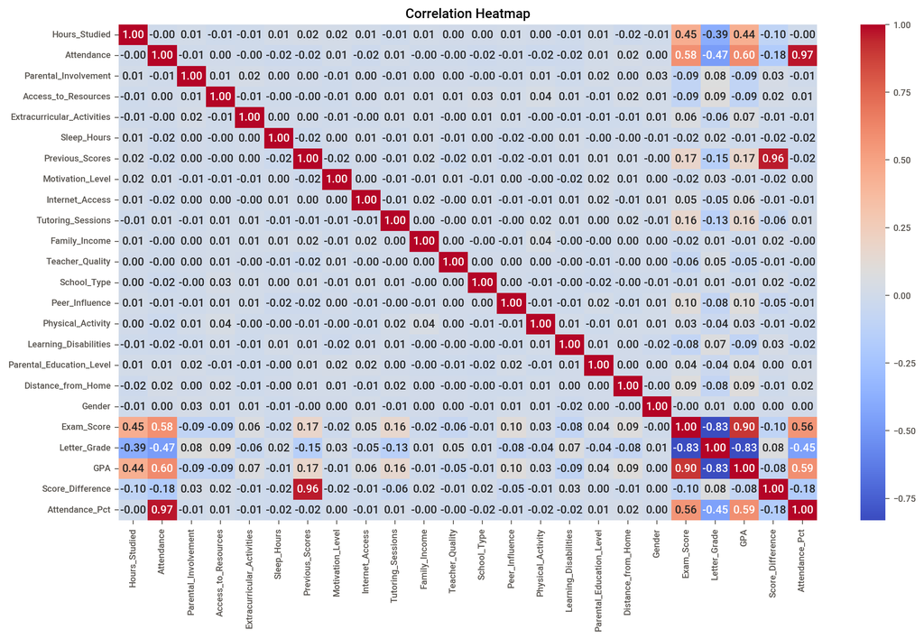

```python
plt.figure(figsize=(14,8))
sns.heatmap(df_encoded.select_dtypes(include=['number']).corr(), annot=True, fmt=".2f",cmap='coolwarm')
plt.title("Correlation Heatmap")
plt.show()
```

```python
df_encoded.info()
```

```
<class 'pandas.core.frame.DataFrame'>
Index: 6378 entries, 0 to 6606
Data columns (total 25 columns):
 #   Column                      Non-Null Count  Dtype
---  ------                      --------------  -----
 0   Hours_Studied               6378 non-null   int64
 1   Attendance                  6378 non-null   int64
 2   Parental_Involvement        6378 non-null   int32
 3   Access_to_Resources         6378 non-null   int32
 4   Extracurricular_Activities  6378 non-null   int32
 5   Sleep_Hours                 6378 non-null   int64
 6   Previous_Scores             6378 non-null   int64
 7   Motivation_Level            6378 non-null   int32
 8   Internet_Access             6378 non-null   int32
 9   Tutoring_Sessions           6378 non-null   int64
```

[output cut: 17 more lines]

```python
from sklearn.model_selection import train_test_split

X = df_encoded.drop(['pass_fail','Exam_Score'],axis=1)
y = df_encoded['Exam_Score']

X_train, X_temp, y_train, y_temp = train_test_split(X, y, test_size=0.3, random_state=42)
X_val, X_test, y_val, y_test = train_test_split(X_temp, y_temp, test_size=0.5, random_state=42)

print(f"Train: {len(X_train)} | Validation: {len(X_val)} | Test: {len(X_test)}")
```

```
Train: 4464 | Validation: 957 | Test: 957
```

```python
X_train
```

|  | Hours_Studied | Attendance | Parental_Involvement | Access_to_Resources | Extracurricular_Activities | Sleep_Hours | Previous_Scores | Motivation_Level | Internet_Access | Tutoring_Sessions | ... | Peer_Influence | Physical_Activity | Learning_Disabilities | Parental_Education_Level | Distance_from_Home | Gender | Letter_Grade | GPA | Score_Difference | Attendance_Pct |
| --- | --- | --- | --- | --- | --- | --- | --- | --- | --- | --- | --- | --- | --- | --- | --- | --- | --- | --- | --- | --- | --- |
| 5955 | 25 | 62 | 2 | 1 | 0 | 6 | 61 | 0 | 1 | 1 | ... | 2 | 4 | 0 | 2 | 1 | 0 | 11 | 0.0 | -3 | 60 |
| 694 | 24 | 73 | 2 | 2 | 1 | 7 | 99 | 2 | 1 | 3 | ... | 1 | 3 | 0 | 1 | 2 | 0 | 10 | 1.3 | 30 | 70 |
| 352 | 25 | 77 | 2 | 1 | 1 | 8 | 65 | 0 | 0 | 0 | ... | 2 | 5 | 0 | 0 | 0 | 0 | 9 | 1.0 | -1 | 70 |
| 3665 | 12 | 80 | 0 | 0 | 1 | 10 | 92 | 0 | 1 | 1 | ... | 2 | 3 | 0 | 2 | 1 | 1 | 8 | 1.7 | 22 | 80 |
| 2430 | 23 | 80 | 1 | 0 | 0 | 6 | 63 | 1 | 1 | 0 | ... | 2 | 2 | 0 | 1 | 2 | 1 | 9 | 1.0 | -3 | 80 |
| ... | ... | ... | ... | ... | ... | ... | ... | ... | ... | ... | ... | ... | ... | ... | ... | ... | ... | ... | ... | ... | ... |
| 3904 | 30 | 70 | 0 | 1 | 0 | 6 | 84 | 0 | 1 | 2 | ... | 2 | 3 | 0 | 2 | 2 | 1 | 8 | 1.7 | 14 | 70 |
| 5378 | 24 | 90 | 1 | 1 | 1 | 9 | 97 | 0 | 1 | 3 | ... | 2 | 4 | 0 | 1 | 2 | 1 | 8 | 1.7 | 26 | 90 |
| 5415 | 24 | 65 | 1 | 0 | 1 | 7 | 52 | 2 | 1 | 1 | ... | 1 | 1 | 0 | 2 | 1 | 0 | 11 | 0.0 | -12 | 60 |
| 5582 | 30 | 91 | 2 | 0 | 1 | 7 | 95 | 1 | 1 | 1 | ... | 2 | 3 | 0 | 0 | 2 | 0 | 6 | 2.0 | 20 | 90 |
| 894 | 28 | 94 | 2 | 0 | 1 | 7 | 80 | 2 | 1 | 3 | ... | 2 | 4 | 0 | 2 | 0 | 1 | 6 | 2.0 | 5 | 90 |

4464 rows × 23 columns

```python
y_train
```

```
5955    64
694     69
352     66
3665    70
2430    66
        ..
3904    70
5378    71
5415    64
5582    75
894     75
Name: Exam_Score, Length: 4464, dtype: int64
```

```python
from sklearn.linear_model import LogisticRegression
from sklearn.tree import DecisionTreeClassifier
from sklearn.ensemble import RandomForestClassifier
```

```python
models = {
    "Logistic Regression": LogisticRegression(max_iter=1000),
    "Decision Tree": DecisionTreeClassifier(random_state=42),
    "Random Forest": RandomForestClassifier(random_state=42)}
```

```python
from sklearn.metrics import accuracy_score

results = {}

for name, model in models.items():
    model.fit(X_train, y_train)
    y_pred = model.predict(X_val)
    acc = accuracy_score(y_val, y_pred) * 100  # accuracy in %
    results[name] = acc
    print(f"{name}: {acc:.2f}%")
```

```
Logistic Regression: 52.46%
Decision Tree: 43.47%
Random Forest: 49.74%
```

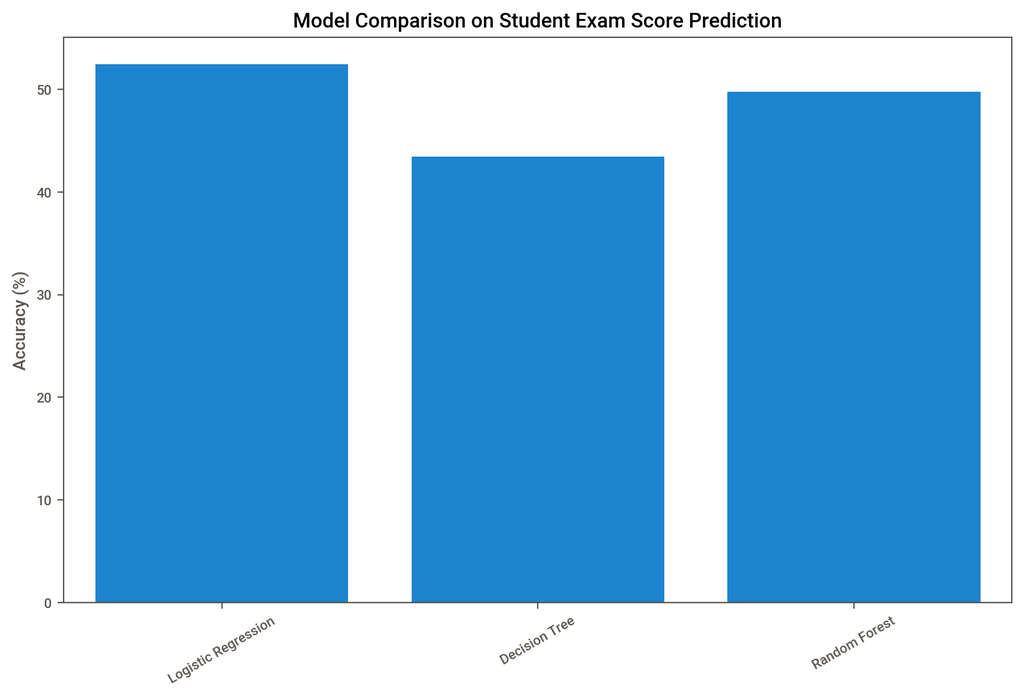

```python
plt.figure(figsize=(10, 6))
sns.barplot(x=list(results.keys()), y=list(results.values()))
plt.xticks(rotation=30)
plt.ylabel("Accuracy (%)")
plt.title("Model Comparison on Student Exam Score Prediction")
plt.show()
```

```python
model_LR = LogisticRegression(max_iter=1000)
model_LR.fit(X_train, y_train)
y_pred_test = model_LR.predict(X_test)
```

```python
y_pred_test
```

```
array([66, 66, 70, 68, 60, 66, 65, 68, 66, 68, 68, 60, 67, 62, 62, 72, 65,
       68, 69, 68, 70, 66, 74, 69, 68, 64, 66, 67, 66, 73, 68, 71, 67, 60,
       64, 67, 71, 70, 70, 65, 68, 67, 74, 66, 65, 67, 65, 70, 70, 69, 64,
       70, 62, 69, 68, 68, 63, 61, 67, 68, 69, 63, 65, 65, 65, 62, 88, 67,
       65, 60, 72, 66, 66, 73, 68, 64, 64, 66, 64, 67, 67, 75, 64, 67, 66,
       65, 67, 68, 67, 70, 67, 67, 72, 67, 67, 68, 66, 69, 68, 62, 70, 71,
       71, 65, 72, 64, 64, 67, 67, 70, 70, 64, 65, 69, 67, 64, 66, 65, 68,
       66, 67, 68, 72, 67, 70, 65, 65, 60, 68, 65, 67, 88, 68, 72, 73, 70,
       72, 69, 67, 67, 62, 70, 69, 68, 70, 68, 67, 68, 68, 63, 74, 68, 67,
       67, 70, 65, 69, 70, 64, 69, 64, 68, 63, 69, 67, 64, 68, 69, 74, 67,
       76, 68, 67, 65, 70, 67, 66, 70, 69, 67, 72, 70, 64, 66, 71, 66, 73,
       74, 66, 68, 67, 64, 69, 61, 64, 69, 66, 62, 62, 69, 70, 64, 65, 66,
       75, 67, 68, 69, 68, 70, 62, 67, 69, 68, 71, 64, 69, 67, 68, 67, 64,
       75, 68, 65, 66, 62, 62, 67, 67, 67, 68, 65, 70, 69, 66, 70, 69, 66,
       64, 70, 65, 67, 66, 62, 64, 69, 65, 64, 63, 74, 69, 67, 65, 65, 68,
```

[output cut: 42 more lines]

```python
df_results = pd.DataFrame({
    'y_test': y_test,
    'y_pred': y_pred_test
})

df_results
```

|  | y_test | y_pred |
| --- | --- | --- |
| 6160 | 66 | 66 |
| 158 | 66 | 66 |
| 4452 | 71 | 70 |
| 1992 | 68 | 68 |
| 1101 | 55 | 60 |
| ... | ... | ... |
| 5500 | 72 | 70 |
| 4561 | 72 | 72 |
| 385 | 63 | 64 |
| 2639 | 64 | 64 |
| 3319 | 73 | 74 |

957 rows × 2 columns

```python
df_results['GPA_test'] = df_results['y_test'].apply(get_letter_grade)
df_results['GPA_pred'] = df_results['y_pred'].apply(get_letter_grade)
df_results.head()
```

|  | y_test | y_pred | GPA_test | GPA_pred |
| --- | --- | --- | --- | --- |
| 6160 | 66 | 66 | D | D |
| 158 | 66 | 66 | D | D |
| 4452 | 71 | 70 | C− | C− |
| 1992 | 68 | 68 | D+ | D+ |
| 1101 | 55 | 60 | F | F |

```python
(df_results['y_test'] != df_results['y_pred']).sum()
```

```
481
```

```python
(df_results['GPA_test'] != df_results['GPA_pred']).sum()
```

```
17
```

```python
diff = df_results[df_results['GPA_test'] != df_results['GPA_pred']]
diff
```

|  | y_test | y_pred | GPA_test | GPA_pred |
| --- | --- | --- | --- | --- |
| 2076 | 84 | 88 | B | B+ |
| 1957 | 79 | 75 | C+ | C |
| 6393 | 98 | 88 | A+ | B+ |
| 5808 | 72 | 76 | C− | C |
| 5777 | 66 | 69 | D | D+ |
| 770 | 94 | 74 | A | C |
| 4295 | 66 | 69 | D | D+ |
| 2421 | 86 | 75 | B | C |
| 6599 | 70 | 76 | C− | C |
| 836 | 94 | 75 | A | C |
| 2812 | 73 | 71 | C | C− |
| 1042 | 65 | 69 | D | D+ |
| 94 | 100 | 95 | A+ | A |
| 6592 | 72 | 73 | C− | C |
| 1926 | 66 | 57 | D | F |
| 1132 | 70 | 76 | C− | C |
| 6202 | 77 | 73 | C+ | C |

Letter Meaning Percentage Range GPA (4.0 scale) A+ Excellent 97–100% 4.0 A Excellent 93–96% 4.0 A− Very good 90–92% 3.7 B+ Good 87–89% 3.3 B Good 83–86% 3.0 B− Fair 80–82% 2.7 C+ Average 77–79% 2.3 C Average 73–76% 2.0 C− Below average 70–72% 1.7 D+ Poor 67–69% 1.3 D Poor 65–66% 1.0 F Fail Below 65% 0.0